# Stat 151A Lab 2

Bryan Liu

August 31, 2018

# The wages dataset

We consider cross-sectional wage data sampled from the 1976 US Population Survey[^1]. It consists of 526 observations of average hourly wages, and various covariates such as education, race, gender, or marital status.

### Loading the dataset

```r
# uncomment the install.packages if you do not have this package
# install.packages('wooldridge')
require('wooldridge')
data('wage1')
head(wage1)
```

```
##   wage educ exper tenure nonwhite female married numdep smsa northcen
## 1 3.10   11     2      0        0      1       0      2    1        0
## 2 3.24   12    22      2        0      1       1      3    1        0
## 3 3.00   11     2      0        0      0       0      2    0        0
## 4 6.00    8    44     28        0      0       1      0    1        0
## 5 5.30   12     7      2        0      0       1      1    0        0
## 6 8.75   16     9      8        0      0       1      0    1        0
##   south west construc ndurman trcommpu trade services profserv profocc
## 1     0    1        0       0        0     0        0        0       0
## 2     0    1        0       0        0     0        1        0       0
## 3     0    1        0       0        0     1        0        0       0
## 4     0    1        0       0        0     0        0        0       0
## 5     0    1        0       0        0     0        0        0       0
## 6     0    1        0       0        0     0        0        1       1
##   clerocc servocc    lwage expersq tenursq
## 1       0       0 1.131402       4       0
## 2       0       1 1.175573     484       4
## 3       0       0 1.098612       4       0
## 4       1       0 1.791759    1936     784
## 5       0       0 1.667707      49       4
## 6       0       0 2.169054      81      64
```

Wage is in dollars per hour. Lets look at its distribution:

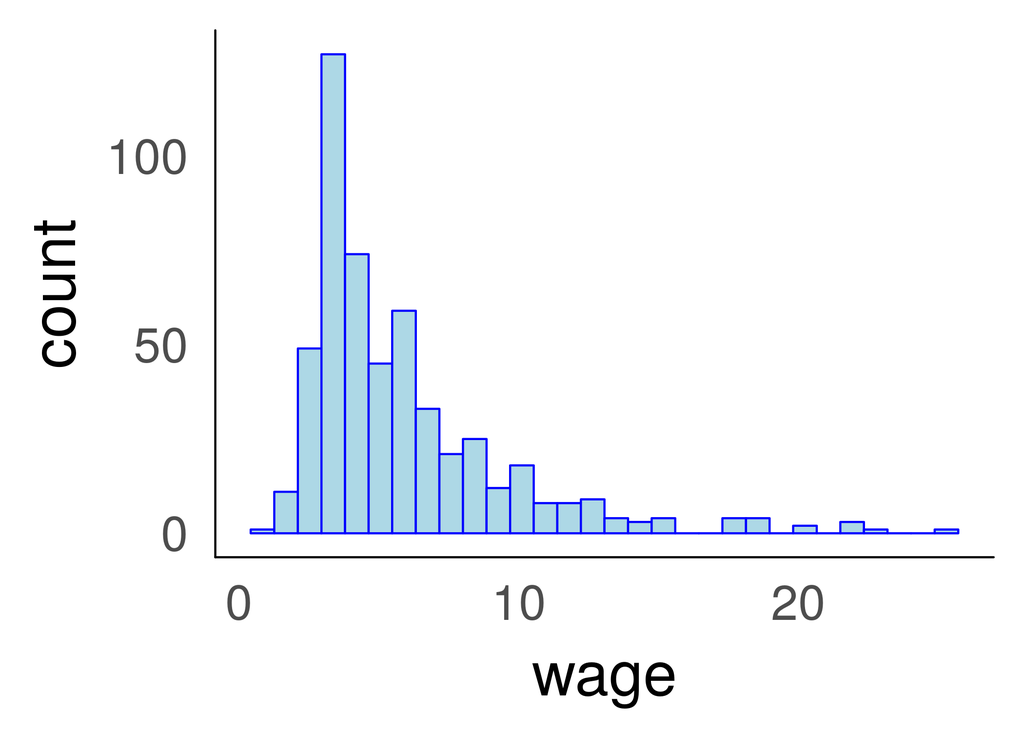

```r
# A histogram of wages
wage1 %>% ggplot() +
  geom_histogram(aes(x = wage),
                  fill = 'light blue',
                  color = 'blue') + blank_theme
```

```r
# For demonstrating ggplot:
# we can color by gender, for example
# wage1 %>% mutate(gender = as.factor(female)) %>%
  # ggplot() +
  # geom_histogram(aes(x = wage, color = gender, fill = gender, dodge = TRUE)) +
  # blank_theme
```

### Simple linear regression

We are going to consider the relationship between education and wages. Lets make a scatterplot!

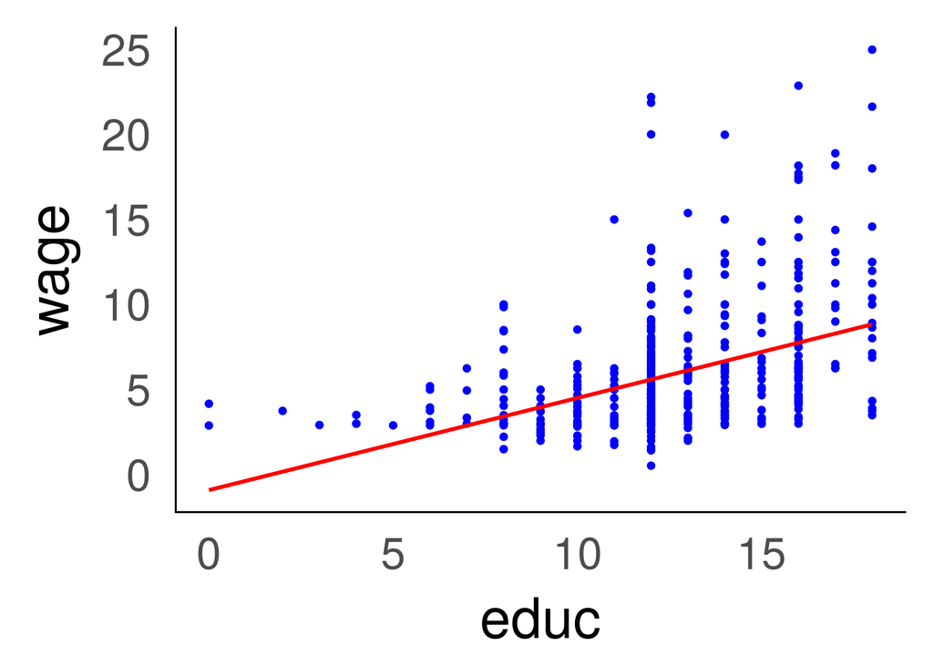

```r
# Make a scatter plot with wages on the y axis, and education on the x axis
wage1 %>%
  ggplot() +
  geom_point(aes(x = educ, y = wage), color = 'blue') +
  blank_theme +
  geom_smooth(aes(x = educ, y = wage), method = "lm",
                        col = "red", se = FALSE)
```

Print the coefficients of the linear model regressing wage on education:

```r
slm <- lm(wage ~ educ, data = wage1)
summary(slm)
```

```
##
## Call:
## lm(formula = wage ~ educ, data = wage1)
##
## Residuals:
##     Min      1Q  Median      3Q     Max
## -5.3396 -2.1501 -0.9674  1.1921 16.6085
##
## Coefficients:
##             Estimate Std. Error t value Pr(>|t|)
## (Intercept) -0.90485    0.68497  -1.321    0.187
## educ         0.54136    0.05325  10.167   <2e-16 ***
## ---
## Signif. codes:  0 '***' 0.001 '**' 0.01 '*' 0.05 '.' 0.1 ' ' 1
##
## Residual standard error: 3.378 on 524 degrees of freedom
## Multiple R-squared:  0.1648, Adjusted R-squared:  0.1632
## F-statistic: 103.4 on 1 and 524 DF,  p-value: < 2.2e-16
```

```r
# abline doesn't work in knitr for some reason
# but works in the console
# y = wage1$wage
# x = wage1$educ
# plot(x, y, xlab = "Education", ylab = "Hourly Wages")
# abline(slm, col = "red")
```

What is the estimated intercept term? What does it mean? Does it make sense?

What is the estimated slope? What does it mean?

Its usually a good ideas to look at residuals. Compute and plot the residuals here:

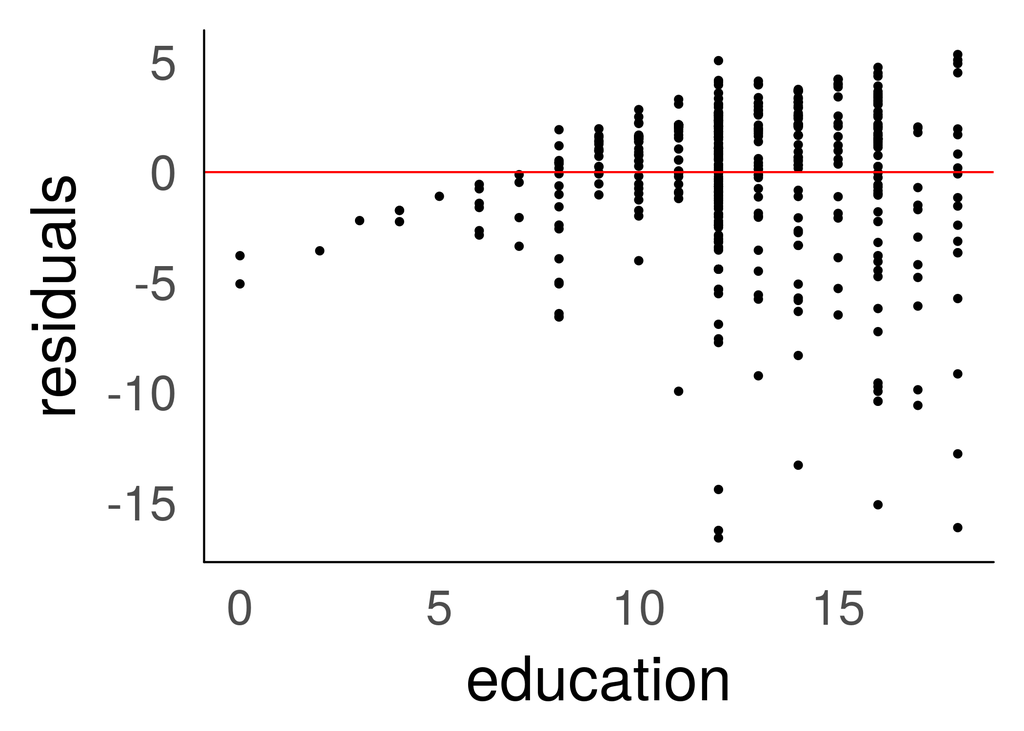

```r
# Compute residuals
pred_wage <- predict(slm, newdata = wage1)
residuals <- pred_wage - wage1$wage

# Plot residuals against education
ggplot() + geom_point(aes(x = wage1$educ, y = residuals)) +
  geom_hline(yintercept = 0.0, color = 'red') +
  xlab('education') + ylab('residuals') + blank_theme
```

Observations about residuals?

Lets redo the plot, but use a log scale for wages. Why might the log scale make more sense?

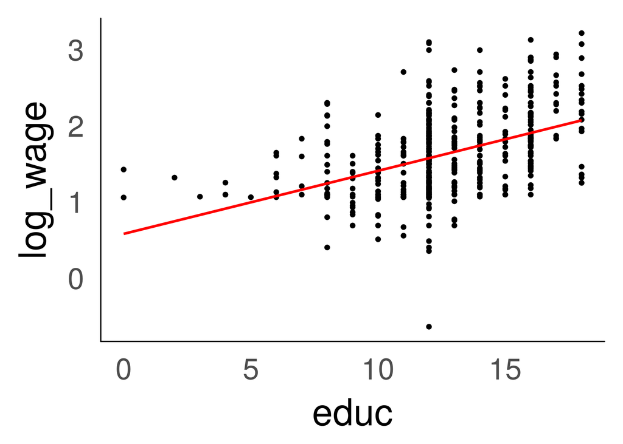

```r
# Make a scatterplot of log(wage) vs education
wage1 %>% mutate(log_wage = log(wage)) %>%
  ggplot() + geom_point(aes(x = educ, y = log_wage)) + blank_theme +
            geom_smooth(aes(x = educ, y = log_wage), method = "lm",
                        col = "red", se = FALSE)
```

Examine the regression coefficients for log wage vs educ:

```r
# Print the regression coefficients for log(wage) vs education
slm2 <- lm(log(wage) ~ educ, data = wage1)
summary(slm2)
```

```
##
## Call:
## lm(formula = log(wage) ~ educ, data = wage1)
##
## Residuals:
##      Min       1Q   Median       3Q      Max
## -2.21158 -0.36393 -0.07263  0.29712  1.52339
##
## Coefficients:
##             Estimate Std. Error t value Pr(>|t|)
## (Intercept) 0.583773   0.097336   5.998 3.74e-09 ***
## educ        0.082744   0.007567  10.935  < 2e-16 ***
## ---
## Signif. codes:  0 '***' 0.001 '**' 0.01 '*' 0.05 '.' 0.1 ' ' 1
##
## Residual standard error: 0.4801 on 524 degrees of freedom
## Multiple R-squared:  0.1858, Adjusted R-squared:  0.1843
## F-statistic: 119.6 on 1 and 524 DF,  p-value: < 2.2e-16
```

Compute residuals again:

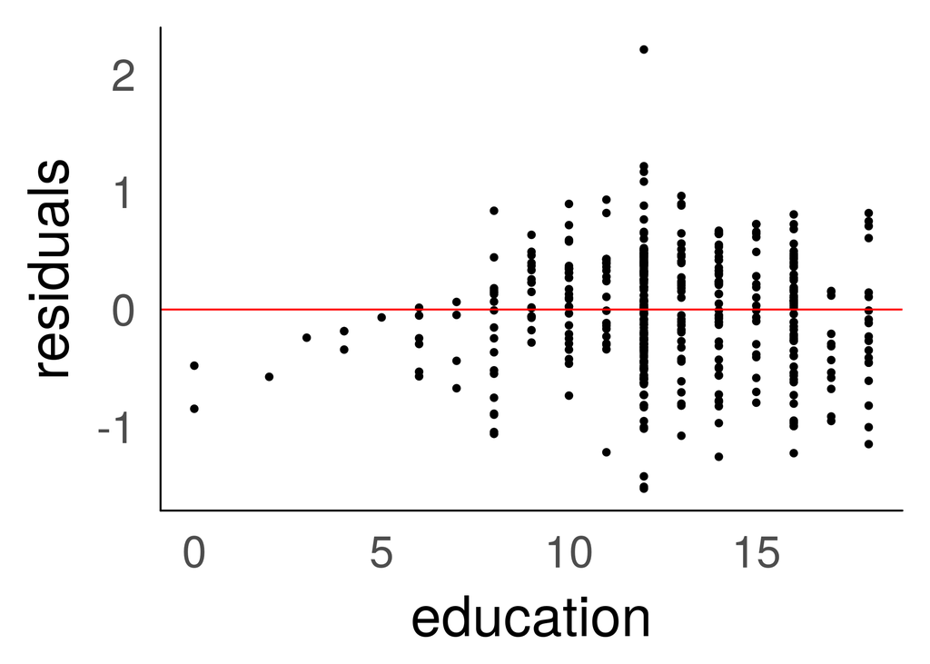

```r
# Compute residuals for log(wage) vs education
pred_logwage <- predict(slm2, newdata = wage1)
residuals2 <- pred_logwage - log(wage1$wage)

# Plot residuals against education
ggplot() + geom_point(aes(x = wage1$educ, y = residuals2)) +
  geom_hline(yintercept = 0.0, color = 'red') +
  xlab('education') + ylab('residuals') + blank_theme
```

Better?

# A simulation experiment

There is an unknown line:

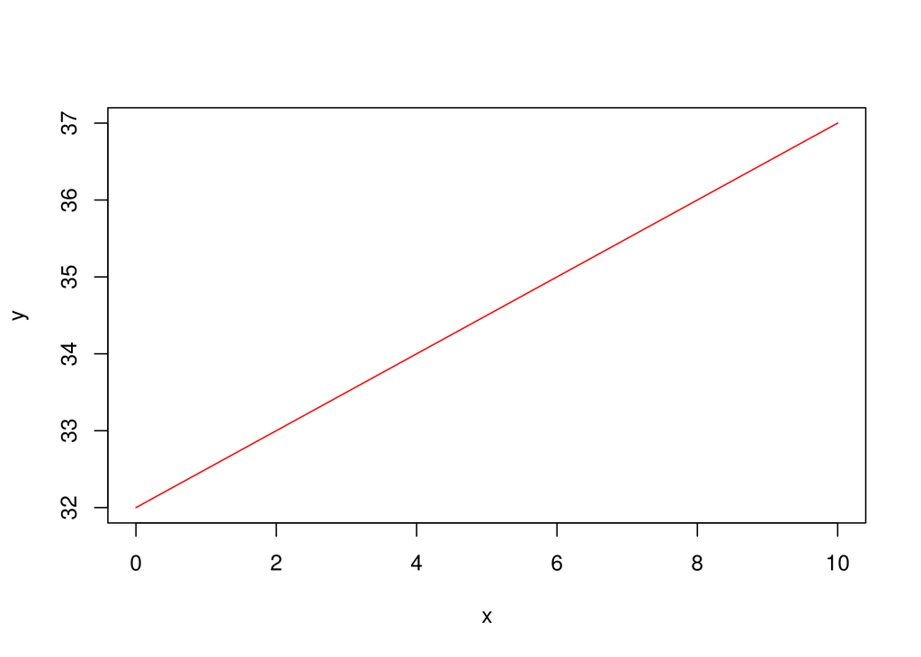

```r
# True parameters (unknown)
beta0 = 32
beta1 = 0.5

# plot the line y = x * beta1 + beta0, for x in [0, 10]
xvals <- seq(0, 10, 0.01)
yvals <- beta0 + beta1*xvals
plot(xvals,
     yvals,
     type = "l",
     xlab = "x", ylab = "y", col = "red")
```

Lets draw data according to the linear regression model. What is the generative model?

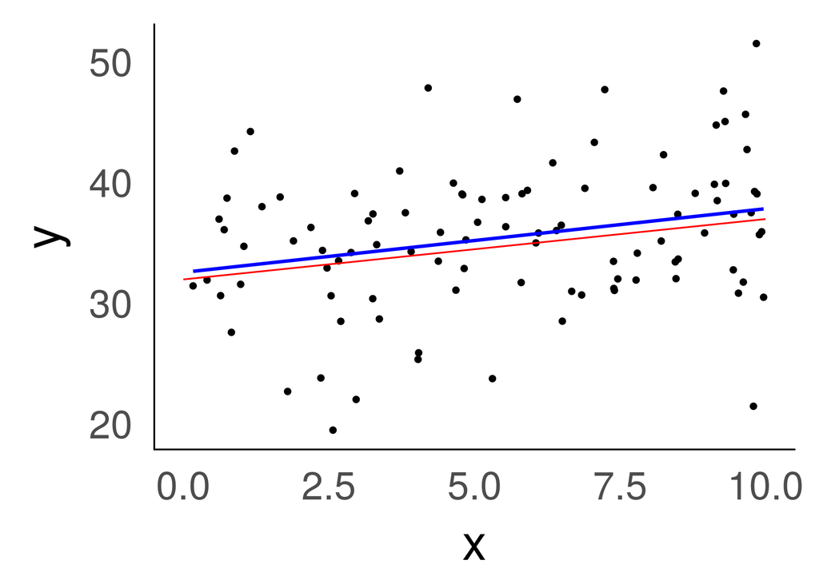

```r
#################
# draw data according to the linear regression model.
#################
n_obs <- 100 # number of observations
sig <- 6 # std error of the y's
x <- runif(n_obs, 0, 10) # draw x's: they will be fixed for our experiment

draw_data <- function(x, beta0, beta1, sig){
  n_obs <- length(x)

  # draw y's
  y = rnorm(n_obs, mean = beta0 + beta1*x, sd = sig)

  return(data.frame(x = x, y = y))
}

dataset <- draw_data(x, beta0, beta1, sig)

# plot the data
ggplot() +
      geom_point(data = dataset, aes(x = x, y = y)) +
      blank_theme +
      # this is the line we wish to recover (in red):
      geom_line(aes(x = xvals, y = yvals), color = 'red') +
      # this is the estimated regression line (in blue):
      geom_smooth(data = dataset,
                  aes(x = x, y = y), method = "lm",
                        col = "blue", se = FALSE)
```

Lets compute the regression coefficients using our simulated dataset:

```r
# Compute the regression coefficients from simulated data:
lm(y ~ x, data = dataset)
```

```
##
## Call:
## lm(formula = y ~ x, data = dataset)
##
## Coefficients:
## (Intercept)            x
##      32.587        0.527
```

Is it unbiased? We can run a simulation to check:

```r
# draw multiple datasets from the model
# and for each dataset, recompute the regression coefficients.

n_trials <- 200

intercepts <- rep(0, n_trials)
slopes <- rep(0, n_trials)
for(i in 1:n_trials){
  dataset <- draw_data(x, beta0, beta1, sig)

  slm <- lm(y ~ x, data = dataset)

  intercepts[i] <- slm$coefficients[1]
  slopes[i] <- slm$coefficients[2]
}
```

What are the distributions of our estimated beta1 and beta0s?

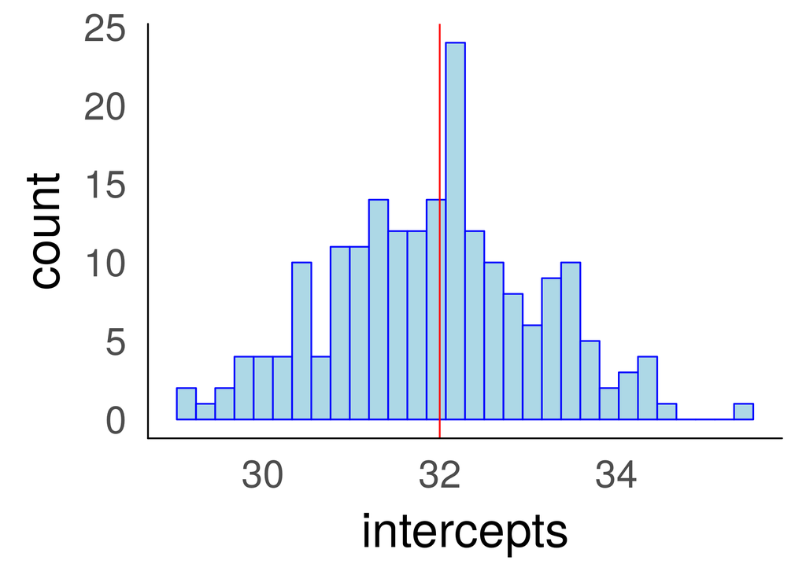

```r
# examine distribution of the intercepts
ggplot() + geom_histogram(aes(x = intercepts),
                          color = 'blue', fill = 'light blue') +
  blank_theme +
  # this is the true intercept
  geom_vline(xintercept = beta0, color = 'red')
```

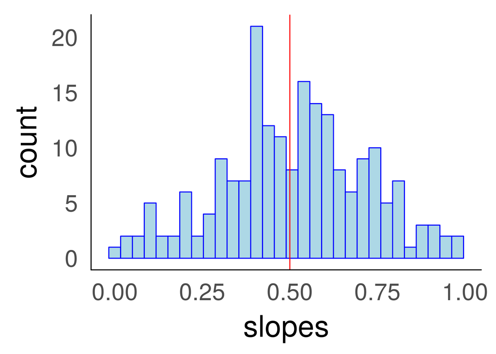

```r
# examine distribution of the slopes
ggplot() + geom_histogram(aes(x = slopes),
                          color = 'blue', fill = 'light blue') +
  blank_theme +
  # this is the true slope
  geom_vline(xintercept = beta1, color = 'red')
```

Do our estimates appear unbiased? What can we say about the variance of the estimates? Do they agree with the formulae discussed in class?

[^1]: Wooldridge, J.~M. (2000), Introductory Econometrics: A Modern Approach, South-Western College Publishing.